# Exploring Data with R

## Multivariate Analysis

```r
D=data.frame(MPG.City=newformed2$MPG.city,MPG.Highway=newformed2$MPG.highway,EPA=newformed2$EPA_ratings)
View(D)
cor(D)
```

```
##              MPG.City MPG.Highway       EPA
## MPG.City    1.0000000   0.9439358 0.9892398
## MPG.Highway 0.9439358   1.0000000 0.9820777
## EPA         0.9892398   0.9820777 1.0000000
```

Mean

```r
M2<- aggregate(Cars93$MPG.highway~Cylinders,Cars93, mean)
M2
```

```
##   Cylinders Cars93$MPG.highway
## 1         3           43.33333
## 2         4           31.44898
## 3         5           24.50000
## 4         6           25.32258
## 5         8           25.00000
## 6    rotary           25.00000
```

Percentile

```r
P2<- tapply(Cars93$MPG.highway,Cars93$Cylinders,quantile)
P2
```

```
## $`3`
##   0%  25%  50%  75% 100%
## 37.0 40.0 43.0 46.5 50.0
##
## $`4`
##   0%  25%  50%  75% 100%
##   22   29   31   33   46
##
## $`5`
##    0%   25%   50%   75%  100%
## 21.00 22.75 24.50 26.25 28.00
##
## $`6`
##   0%  25%  50%  75% 100%
## 20.0 24.0 26.0 27.5 30.0
##
## $`8`
##   0%  25%  50%  75% 100%
##   22   25   25   26   26
##
## $rotary
##   0%  25%  50%  75% 100%
##   25   25   25   25   25
```

Graphical

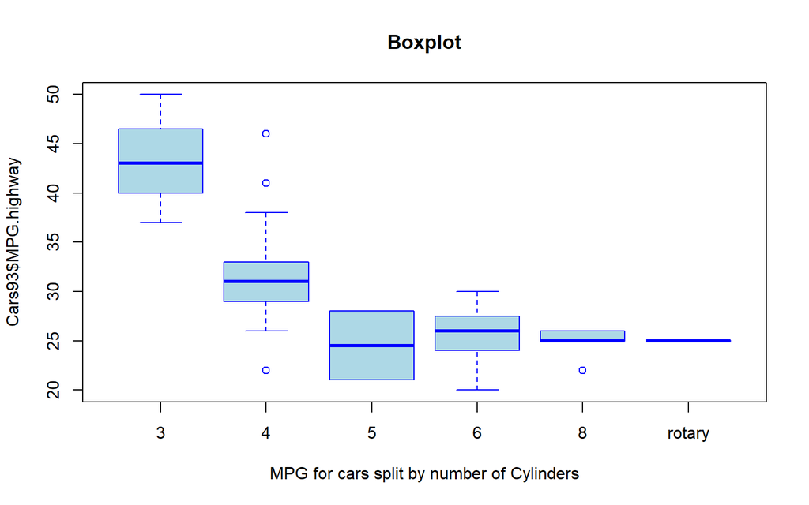

```r
B3<- boxplot(Cars93$MPG.highway~Cars93$Cylinders, col = "lightblue", main = "Boxplot", border = "blue",xlab = "MPG for cars split by number of Cylinders")
```

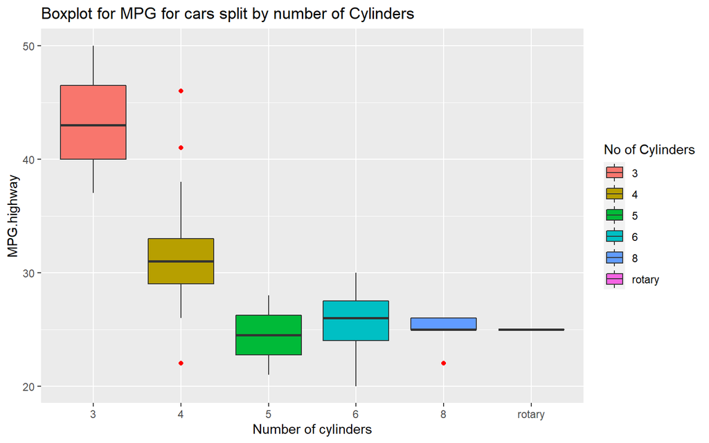

```r
GB3<- ggplot(data=Cars93, aes(x=Cylinders, y=MPG.highway, fill = Cylinders))+
  geom_boxplot(outlier.colour = "red")+
  ggtitle("Boxplot for MPG for cars split by number of Cylinders")+
  labs(x="Number of cylinders", fill = "No of Cylinders")
GB3
```

```r
AA<-summary(aov(Cars93$MPG.highway~Cars93$Cylinders))
AA
```

```
##                  Df Sum Sq Mean Sq F value   Pr(>F)
## Cars93$Cylinders  5   1497  299.45    23.3 8.83e-15 ***
## Residuals        87   1118   12.85
## ---
## Signif. codes:  0 '***' 0.001 '**' 0.01 '*' 0.05 '.' 0.1 ' ' 1
```

Origin in Cars93 Dataset is a Binary Categorical Variable because it has exactly 2 levels;USA and Non-USA. Let us consider Origin as well as two polytomous variables; Type and Passengers. Type variable has 6 levels,Origin has 2 levels and Passengers has 6 levels.

```r
table(Cars93$Type)
```

```
##
## Compact   Large Midsize   Small  Sporty     Van
##      16      11      22      21      14       9
```

```r
table(Cars93$Origin)
```

```
##
##     USA non-USA
##      48      45
```

```r
table(Cars93$Passengers)
```

```
##
##  2  4  5  6  7  8
##  2 23 41 18  8  1
```

```r
ftable(Cars93$Type,Cars93$Origin,Cars93$Passengers)
```

```
##                   2  4  5  6  7  8
##
## Compact USA       0  0  5  2  0  0
##         non-USA   0  1  8  0  0  0
## Large   USA       0  0  0 11  0  0
##         non-USA   0  0  0  0  0  0
## Midsize USA       0  0  6  4  0  0
##         non-USA   0  2  9  1  0  0
## Small   USA       0  2  5  0  0  0
##         non-USA   0  6  8  0  0  0
## Sporty  USA       1  7  0  0  0  0
##         non-USA   1  5  0  0  0  0
## Van     USA       0  0  0  0  4  1
##         non-USA   0  0  0  0  4  0
```

Counts are listed for each Type, split by Origin and 6 levels of Passengers

## Parametric Test

Code snippet for performing t-test

```r
sourceData <- Cars93
tTestData <- t.test(sourceData$Min.Price, sourceData$Max.Price)
names(tTestData)
```

```
##  [1] "statistic"   "parameter"   "p.value"     "conf.int"    "estimate"
##  [6] "null.value"  "stderr"      "alternative" "method"      "data.name"
```

```r
tTestData$statistic
```

```
##         t
## -3.269876
```

```r
tTestData$p.value
```

```
## [1] 0.001295767
```

## Non Parametric Test

```r
library(MASS)
d1<-Cars93
shapiro.test(d1$Price)
```

```
##
##  Shapiro-Wilk normality test
##
## data:  d1$Price
## W = 0.88051, p-value = 4.235e-07
```

```r
wilcox.test(d1$Price,mu=1000,
            alternative="greater",
            conf.level=0.9)
```

```
##
##  Wilcoxon signed rank test with continuity correction
##
## data:  d1$Price
## V = 0, p-value = 1
## alternative hypothesis: true location is greater than 1000
```

```r
str(d1)
```

```
## 'data.frame':    93 obs. of  27 variables:
##  $ Manufacturer      : Factor w/ 32 levels "Acura","Audi",..: 1 1 2 2 3 4 4 4 4 5 ...
##  $ Model             : Factor w/ 93 levels "100","190E","240",..: 49 56 9 1 6 24 54 74 73 35 ...
##  $ Type              : Factor w/ 6 levels "Compact","Large",..: 4 3 1 3 3 3 2 2 3 2 ...
##  $ Min.Price         : num  12.9 29.2 25.9 30.8 23.7 14.2 19.9 22.6 26.3 33 ...
##  $ Price             : num  15.9 33.9 29.1 37.7 30 15.7 20.8 23.7 26.3 34.7 ...
##  $ Max.Price         : num  18.8 38.7 32.3 44.6 36.2 17.3 21.7 24.9 26.3 36.3 ...
##  $ MPG.city          : int  25 18 20 19 22 22 19 16 19 16 ...
##  $ MPG.highway       : int  31 25 26 26 30 31 28 25 27 25 ...
##  $ AirBags           : Factor w/ 3 levels "Driver & Passenger",..: 3 1 2 1 2 2 2 2 2 2 ...
##  $ DriveTrain        : Factor w/ 3 levels "4WD","Front",..: 2 2 2 2 3 2 2 3 2 2 ...
##  $ Cylinders         : Factor w/ 6 levels "3","4","5","6",..: 2 4 4 4 2 2 4 4 4 5 ...
##  $ EngineSize        : num  1.8 3.2 2.8 2.8 3.5 2.2 3.8 5.7 3.8 4.9 ...
##  $ Horsepower        : int  140 200 172 172 208 110 170 180 170 200 ...
##  $ RPM               : int  6300 5500 5500 5500 5700 5200 4800 4000 4800 4100 ...
##  $ Rev.per.mile      : int  2890 2335 2280 2535 2545 2565 1570 1320 1690 1510 ...
##  $ Man.trans.avail   : Factor w/ 2 levels "No","Yes": 2 2 2 2 2 1 1 1 1 1 ...
##  $ Fuel.tank.capacity: num  13.2 18 16.9 21.1 21.1 16.4 18 23 18.8 18 ...
##  $ Passengers        : Factor w/ 6 levels "2","4","5","6",..: 3 3 3 4 2 4 4 4 3 4 ...
##  $ Length            : int  177 195 180 193 186 189 200 216 198 206 ...
##  $ Wheelbase         : int  102 115 102 106 109 105 111 116 108 114 ...
##  $ Width             : int  68 71 67 70 69 69 74 78 73 73 ...
##  $ Turn.circle       : int  37 38 37 37 39 41 42 45 41 43 ...
##  $ Rear.seat.room    : num  26.5 30 28 31 27 28 30.5 30.5 26.5 35 ...
##  $ Luggage.room      : int  11 15 14 17 13 16 17 21 14 18 ...
##  $ Weight            : int  2705 3560 3375 3405 3640 2880 3470 4105 3495 3620 ...
##  $ Origin            : Factor w/ 2 levels "USA","non-USA": 2 2 2 2 2 1 1 1 1 1 ...
##  $ Make              : Factor w/ 93 levels "Acura Integra",..: 1 2 4 3 5 6 7 9 8 10 ...
```

```r
wilcox.test(Fuel.tank.capacity~Origin, data=d1)
```

```
##
##  Wilcoxon rank sum test with continuity correction
##
## data:  Fuel.tank.capacity by Origin
## W = 1187, p-value = 0.4121
## alternative hypothesis: true location shift is not equal to 0
```

```r
kruskal.test(Type~Cylinders, data=d1)
```

```
##
##  Kruskal-Wallis rank sum test
##
## data:  Type by Cylinders
## Kruskal-Wallis chi-squared = 5.2278, df = 5, p-value = 0.3887
```

```r
kruskal.test(Manufacturer~Origin, data=d1)
```

```
##
##  Kruskal-Wallis rank sum test
##
## data:  Manufacturer by Origin
## Kruskal-Wallis chi-squared = 14.93, df = 1, p-value = 0.0001116
```

## Linear Regression

In linear regression, the relationship is estimated between two variables; one response variable and one predictor variable

Plotting the line of best fit,

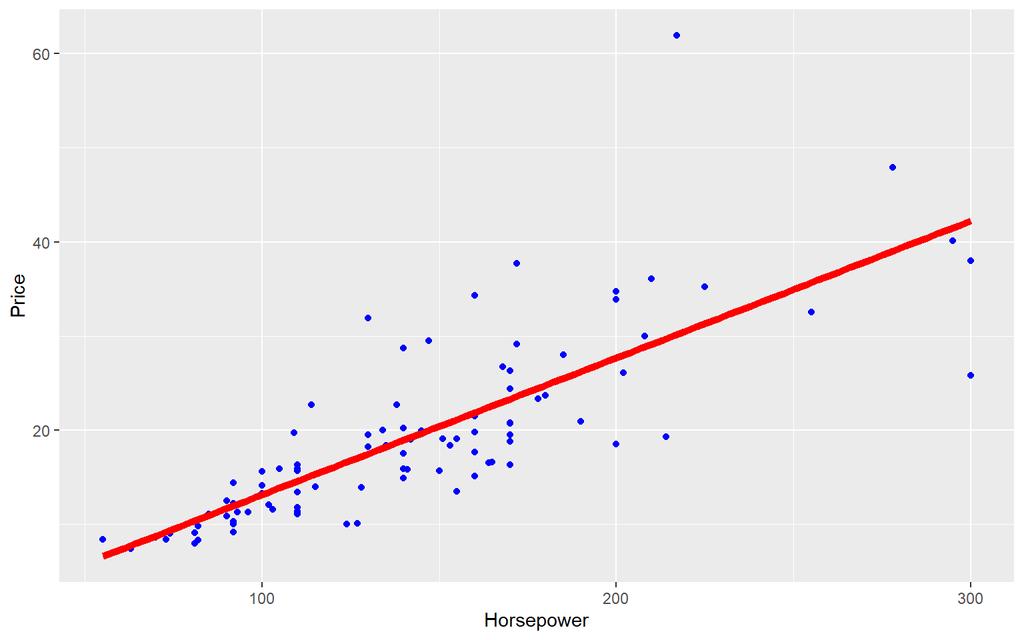

```r
G1=ggplot(Cars93,aes(Horsepower,Price))+
  geom_point(color="blue")+
  geom_smooth(formula = y ~ x, method="lm",se=F,size=2,color="red")
G1
```

Comparing Response variable with Numeric,

```r
fit0=lm(Price~Horsepower,data=Cars93)
fit0
```

```
##
## Call:
## lm(formula = Price ~ Horsepower, data = Cars93)
##
## Coefficients:
## (Intercept)   Horsepower
##     -1.3988       0.1454
```

```r
summary(fit0)
```

```
##
## Call:
## lm(formula = Price ~ Horsepower, data = Cars93)
##
## Residuals:
##     Min      1Q  Median      3Q     Max
## -16.413  -2.792  -0.821   1.803  31.753
##
## Coefficients:
##             Estimate Std. Error t value Pr(>|t|)
## (Intercept)  -1.3988     1.8200  -0.769    0.444
## Horsepower    0.1454     0.0119  12.218   <2e-16 ***
## ---
## Signif. codes:  0 '***' 0.001 '**' 0.01 '*' 0.05 '.' 0.1 ' ' 1
##
## Residual standard error: 5.977 on 91 degrees of freedom
## Multiple R-squared:  0.6213, Adjusted R-squared:  0.6171
## F-statistic: 149.3 on 1 and 91 DF,  p-value: < 2.2e-16
```

Comparing response variable with Categorical/Factor variable

```r
fit1=lm(Price~Type,data=Cars93)
summary(fit1)
```

```
##
## Call:
## lm(formula = Price ~ Type, data = Cars93)
##
## Residuals:
##     Min      1Q  Median      3Q     Max
## -13.318  -4.713  -0.918   1.787  34.682
##
## Coefficients:
##             Estimate Std. Error t value Pr(>|t|)
## (Intercept)  18.2125     1.9258   9.457  5.2e-15 ***
## TypeLarge     6.0875     3.0172   2.018 0.046713 *
## TypeMidsize   9.0057     2.5310   3.558 0.000608 ***
## TypeSmall    -8.0458     2.5563  -3.148 0.002256 **
## TypeSporty    1.1804     2.8191   0.419 0.676467
## TypeVan       0.8875     3.2097   0.277 0.782815
## ---
## Signif. codes:  0 '***' 0.001 '**' 0.01 '*' 0.05 '.' 0.1 ' ' 1
##
## Residual standard error: 7.703 on 87 degrees of freedom
## Multiple R-squared:  0.3986, Adjusted R-squared:  0.364
## F-statistic: 11.53 on 5 and 87 DF,  p-value: 1.477e-08
```

Reordering of levels

```r
Cars93$Type1=relevel(Cars93$Type,ref="Van")

fit_reordered=lm(Price~Type1,data=Cars93)
fit_reordered
```

```
##
## Call:
## lm(formula = Price ~ Type1, data = Cars93)
##
## Coefficients:
##  (Intercept)  Type1Compact    Type1Large  Type1Midsize    Type1Small
##      19.1000       -0.8875        5.2000        8.1182       -8.9333
##  Type1Sporty
##       0.2929
```

## Multiple Regression

Multiple regression is an extension of linear regression into relationship between more than two variables. Here, Response Variable is Price (Numeric) and explanatory variables are Horsepower, Origin, Weight, MPG City and MPG highway.

```r
fit2=lm(Price~Horsepower+Origin+Weight+MPG.city+MPG.highway,data=Cars93)
summary(fit2)
```

```
##
## Call:
## lm(formula = Price ~ Horsepower + Origin + Weight + MPG.city +
##     MPG.highway, data = Cars93)
##
## Residuals:
##      Min       1Q   Median       3Q      Max
## -12.1901  -3.2190  -0.4889   2.3477  30.3087
##
## Coefficients:
##                Estimate Std. Error t value Pr(>|t|)
## (Intercept)   -2.098360  10.549800  -0.199  0.84280
## Horsepower     0.115767   0.017421   6.645 2.53e-09 ***
## Originnon-USA  4.002711   1.272057   3.147  0.00226 **
## Weight         0.002157   0.002105   1.025  0.30824
## MPG.city      -0.280356   0.369713  -0.758  0.45032
## MPG.highway    0.091537   0.349840   0.262  0.79421
## ---
## Signif. codes:  0 '***' 0.001 '**' 0.01 '*' 0.05 '.' 0.1 ' ' 1
##
## Residual standard error: 5.709 on 87 degrees of freedom
## Multiple R-squared:  0.6696, Adjusted R-squared:  0.6507
## F-statistic: 35.27 on 5 and 87 DF,  p-value: < 2.2e-16
```

SIGNIFICANCE OF VARIABLE - Compared to other variables, Horsepower has a greater effect on Price.

QUANTUM OF ASSOCIAION - If the weight or MPG of the car changes, it will not have much impact on the Price. Whereas, the Origin have a greater impact on Price with regard to Magnitude.

The coefficient of Originnon-USA is 4. This indicates that vehicles manufactured outside of the USA carry a price tag that is on average $4 thousand dollars higher than vehicles manufactered in the US.

MPG.highway does not appear to have much association with Price. The coefficient of MPG.highway is close to 0 and is not statistically significant.

Effect of reordering

```r
cbind(fit1$coefficients,fit_reordered$coefficients)
```

```
##                  [,1]       [,2]
## (Intercept) 18.212500 19.1000000
## TypeLarge    6.087500 -0.8875000
## TypeMidsize  9.005682  5.2000000
## TypeSmall   -8.045833  8.1181818
## TypeSporty   1.180357 -8.9333333
## TypeVan      0.887500  0.2928571
```

Confidence Interval

```r
confint(fit2,level=0.99)
```

```
##                       0.5 %       99.5 %
## (Intercept)   -29.881547117 25.684826298
## Horsepower      0.069889615  0.161644808
## Originnon-USA   0.652712793  7.352708234
## Weight         -0.003385524  0.007699729
## MPG.city       -1.254004780  0.693293044
## MPG.highway    -0.829777731  1.012851156
```

Unlike other variables, Horsepower and Origin are Significant. (Same sign-Significant)

Scaling of metric Variables

```r
fit_actual=lm(Price~Horsepower,data=Cars93)
summary(Cars93$Horsepower)
```

```
##    Min. 1st Qu.  Median    Mean 3rd Qu.    Max.
##    55.0   103.0   140.0   143.8   170.0   300.0
```

```r
Cars93$Horsepower_scaled=scale(Cars93$Horsepower,center=mean(Cars93$Horsepower),scale=F)
summary(Cars93$Horsepower_scaled)
```

```
##        V1
##  Min.   :-88.828
##  1st Qu.:-40.828
##  Median : -3.828
##  Mean   :  0.000
##  3rd Qu.: 26.172
##  Max.   :156.172
```

After scaling, mean has become zero and the value of other items has been reduced from mean. Eg(Median=140-143.8= -3.8)

```r
fit_scaled=lm(Price~Horsepower_scaled,data=Cars93)
summary_actual=summary.lm(fit_actual);s_centered=summary.lm(fit_scaled)
summary_actual$coefficients[,1:2];s_centered$coefficients[,1:2]
```

```
##               Estimate Std. Error
## (Intercept) -1.3987691  1.8200164
## Horsepower   0.1453712  0.0118978
```

```
##                     Estimate Std. Error
## (Intercept)       19.5096774  0.6197811
## Horsepower_scaled  0.1453712  0.0118978
```

The standard error reduces after scaling the metric variable

## Residuals

```r
fit=lm(Price~Type+Origin,data=Cars93)
fit
```

```
##
## Call:
## lm(formula = Price ~ Type + Origin, data = Cars93)
##
## Coefficients:
##   (Intercept)      TypeLarge    TypeMidsize      TypeSmall     TypeSporty
##        15.436          8.864          9.090         -8.560          1.841
##       TypeVan  Originnon-USA
##         1.470          4.936
```

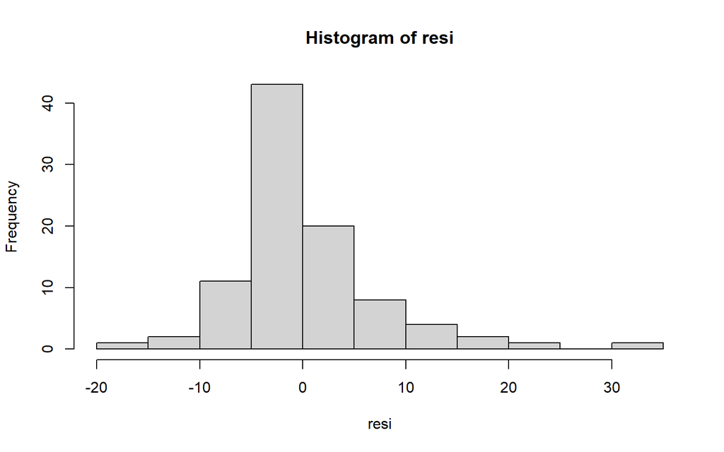

```r
resi=fit$residuals
hist(resi)
```

```r
mean(resi)
```

```
## [1] 2.479395e-16
```

```r
sd(resi)
```

```
## [1] 7.13416
```

```r
n=nrow(Cars93)
k=length(fit$coefficients)-1
```

TSS-Total Sum of Square

```r
ybar=mean(Cars93$Price)
Y=Cars93$Price
TSS=sum((Y-ybar)^2)
```

RSS-Residual Sum of Square

```r
RSS=sum(resi^2)
RSE=sqrt((1/(n-2))*RSS)
```

ESS-Explained Sum of Square

```r
fitt=fit$fitted.values
ESS= sum((fitt-ybar)^2)
ESS+RSS
```

```
## [1] 8584.021
```

R squared

```r
Rsquared=ESS/TSS
1-(RSS/TSS)
```

```
## [1] 0.4545151
```

Adjusted R squared

```r
1-((1-Rsquared)*(n-1)/(n-k-1))
```

```
## [1] 0.416458
```

R squared value is low. Therefore, it is essential to select a model

Model Selection(By means of Anova)

```r
fit=lm(Price~Type+Origin,data=Cars93)
summary(fit)
```

```
##
## Call:
## lm(formula = Price ~ Type + Origin, data = Cars93)
##
## Residuals:
##     Min      1Q  Median      3Q     Max
## -15.562  -3.512  -1.512   2.328  32.438
##
## Coefficients:
##               Estimate Std. Error t value Pr(>|t|)
## (Intercept)     15.436      2.068   7.464 6.34e-11 ***
## TypeLarge        8.864      3.038   2.918 0.004494 **
## TypeMidsize      9.090      2.425   3.749 0.000321 ***
## TypeSmall       -8.560      2.455  -3.487 0.000771 ***
## TypeSporty       1.841      2.710   0.680 0.498588
## TypeVan          1.470      3.081   0.477 0.634422
## Originnon-USA    4.936      1.662   2.970 0.003864 **
## ---
## Signif. codes:  0 '***' 0.001 '**' 0.01 '*' 0.05 '.' 0.1 ' ' 1
##
## Residual standard error: 7.379 on 86 degrees of freedom
## Multiple R-squared:  0.4545, Adjusted R-squared:  0.4165
## F-statistic: 11.94 on 6 and 86 DF,  p-value: 1.038e-09
```

```r
fitA=lm(Price~Type+Origin+AirBags+DriveTrain,data=Cars93)
summary(fitA)
```

```
##
## Call:
## lm(formula = Price ~ Type + Origin + AirBags + DriveTrain, data = Cars93)
##
## Residuals:
##      Min       1Q   Median       3Q      Max
## -11.7105  -3.8356  -0.5542   2.5619  23.1214
##
## Coefficients:
##                    Estimate Std. Error t value Pr(>|t|)
## (Intercept)         21.7937     3.4785   6.265 1.63e-08 ***
## TypeLarge            4.3663     2.7703   1.576 0.118859
## TypeMidsize          6.9868     2.1542   3.243 0.001709 **
## TypeSmall           -5.2985     2.2760  -2.328 0.022378 *
## TypeSporty          -0.9227     2.4180  -0.382 0.703752
## TypeVan              3.4883     3.0145   1.157 0.250560
## Originnon-USA        4.0587     1.4538   2.792 0.006521 **
## AirBagsDriver only  -4.8157     1.9413  -2.481 0.015161 *
## AirBagsNone         -8.5701     2.3327  -3.674 0.000425 ***
## DriveTrainFront     -1.5011     2.5052  -0.599 0.550710
## DriveTrainRear       5.9395     3.0015   1.979 0.051188 .
## ---
## Signif. codes:  0 '***' 0.001 '**' 0.01 '*' 0.05 '.' 0.1 ' ' 1
##
## Residual standard error: 6.412 on 82 degrees of freedom
## Multiple R-squared:  0.6073, Adjusted R-squared:  0.5594
## F-statistic: 12.68 on 10 and 82 DF,  p-value: 4.922e-13
```

```r
anova(fit,fitA,test="F")
```

```
## Analysis of Variance Table
##
## Model 1: Price ~ Type + Origin
## Model 2: Price ~ Type + Origin + AirBags + DriveTrain
##   Res.Df    RSS Df Sum of Sq      F    Pr(>F)
## 1     86 4682.5
## 2     82 3371.3  4    1311.2 7.9728 1.764e-05 ***
## ---
## Signif. codes:  0 '***' 0.001 '**' 0.01 '*' 0.05 '.' 0.1 ' ' 1
```

## Logistic Regression

The Logistic Regression is a regression model in which the response variable has categorical values

Here, Response Variable is binary

```r
tt=table(Cars93$Origin)
tt
```

```
##
##     USA non-USA
##      48      45
```

```r
odds=tt[2]/tt[1]
odds
```

```
## non-USA
##  0.9375
```

Binomial is for accommodating binary variable. Origin is a respone variable with 2 levels

```r
fit3=glm(Origin~1,data=Cars93,family=binomial())
```

As it is in Log scale, let us Exponentiate

```r
exp(fit3$coefficient)
```

```
## (Intercept)
##      0.9375
```

Here, response and predictor are Binary

```r
ttt=table(Cars93$Origin, Cars93$Man.trans.avail)
ttt
```

```
##
##           No Yes
##   USA     26  22
##   non-USA  6  39
```

```r
ODDS=(ttt[1,1]*ttt[2,2]/ttt[1,2]/ttt[2,1])
ODDS
```

```
## [1] 7.681818
```

Basically, it is 26X39/6X22 = 7.68

```r
fit4=glm(Origin~Man.trans.avail,data=Cars93,family=binomial())
summary(fit4)
```

```
##
## Call:
## glm(formula = Origin ~ Man.trans.avail, family = binomial(),
##     data = Cars93)
##
## Deviance Residuals:
##     Min       1Q   Median       3Q      Max
## -1.4282  -0.6444  -0.6444   0.9458   1.8297
##
## Coefficients:
##                    Estimate Std. Error z value Pr(>|z|)
## (Intercept)         -1.4663     0.4529  -3.238 0.001205 **
## Man.trans.availYes   2.0389     0.5256   3.879 0.000105 ***
## ---
## Signif. codes:  0 '***' 0.001 '**' 0.01 '*' 0.05 '.' 0.1 ' ' 1
##
## (Dispersion parameter for binomial family taken to be 1)
##
##     Null deviance: 128.83  on 92  degrees of freedom
## Residual deviance: 110.65  on 91  degrees of freedom
## AIC: 114.65
##
## Number of Fisher Scoring iterations: 4
```

```r
exp(fit4$coefficients[2])
```

```
## Man.trans.availYes
##           7.681818
```

## Conclusion

At the end of this project, we as a team were able to choose and analyse a dataset through various types of visualizations. The function as. factor was useful to explicitly change variables to factors. We made use of packages like ggplot2 and explored all possible options with the appropriate titles and labels. We even solved and answered few questions which helped us to understand the subject in a better way. Both non parametric and parametric tests were performed to study the statistical distributions of the dataset. We also learned the various statistical models (regression) that analyzes the relationship between response and explanatory variables. Along with that, we were able to grasp the concepts of coefficients and residuals. Finally, we acquired the skills that are needed to produce a document using R Markdown.

On the whole, this project gave us an insight on how to do statistical analysis and explore data science using R language. We were extremely interactive and enjoyed sharing ideas with each other.We thank our professor Mr. Subbiah for giving us the opportunity to work on such an innovative project.

[figure not shown]

**Submitted by:** *Group 13*

19/UAFA/109-Sarah

19/UAFA/130-Manasa

19/UAFA/160-Sushmitha

19/UAFA/163-Harini

19/UAFA/176-Linsha